# Part I - Exploration on Ford GoBike System Data

## Introduction

This data set includes information about individual rides made in a bike-sharing system covering the greater San Francisco Bay area.

This dataset contains information on 183412 bike trips carried out during the month of february in the year 2019.

## Preliminary Wrangling

```python
# import all packages and set plots to be embedded inline
import numpy as np
import pandas as pd
import matplotlib.pyplot as plt
import seaborn as sns
import datetime as dt
import os
```

We load our dataset and look at its properties

```python
# Dataset load
df = pd.read_csv('./201902-fordgobike-tripdata.csv')
df.shape
```

```
(183412, 16)
```

```python
df.sample(5)
```

|  | duration_sec | start_time | end_time | start_station_id | start_station_name | start_station_latitude | start_station_longitude | end_station_id | end_station_name | end_station_latitude | end_station_longitude | bike_id | user_type | member_birth_year | member_gender | bike_share_for_all_trip |
| --- | --- | --- | --- | --- | --- | --- | --- | --- | --- | --- | --- | --- | --- | --- | --- | --- |
| 120375 | 277 | 2019-02-11 17:09:28.5680 | 2019-02-11 17:14:06.3350 | 36.0 | Folsom St at 3rd St | 37.783830 | -122.398870 | 67.0 | San Francisco Caltrain Station 2 (Townsend St... | 37.776639 | -122.395526 | 5469 | Customer | NaN | NaN | No |
| 170829 | 406 | 2019-02-04 07:39:07.4700 | 2019-02-04 07:45:54.0600 | 61.0 | Howard St at 8th St | 37.776513 | -122.411306 | 101.0 | 15th St at Potrero Ave | 37.767079 | -122.407359 | 5392 | Subscriber | 1996.0 | Male | No |
| 135830 | 591 | 2019-02-08 11:34:38.6410 | 2019-02-08 11:44:30.3530 | 305.0 | Ryland Park | 37.342725 | -121.895617 | 280.0 | San Fernando St at 7th St | 37.337122 | -121.883215 | 4299 | Subscriber | 1993.0 | Male | Yes |
| 141008 | 289 | 2019-02-07 18:27:28.2720 | 2019-02-07 18:32:17.8730 | 36.0 | Folsom St at 3rd St | 37.783830 | -122.398870 | 27.0 | Beale St at Harrison St | 37.788059 | -122.391865 | 1798 | Subscriber | 1985.0 | Male | Yes |
| 133980 | 337 | 2019-02-08 18:06:11.3760 | 2019-02-08 18:11:48.4440 | 30.0 | San Francisco Caltrain (Townsend St at 4th St) | 37.776598 | -122.395282 | 27.0 | Beale St at Harrison St | 37.788059 | -122.391865 | 5468 | Subscriber | 1984.0 | Male | No |

### What is the structure of your dataset?

The dataframe consist of 183412 rows (one for each ride) and 16 columns.

In the columns we have information on the following variables:

- duration_sec: trip duration in seconds
- start_time: date and time of the start of the trip
- end_time: date and time of the end of the trip
- start_station_id: each station has a unique number id. These are the start station id
- start_station_name
- start_station_latitude
- start_station_longitude
- end_station_id
- end_station_name
- end_station_latitude
- end_station_longitude
- bike_id: each bike has a unique number of identification
- user_type: indicates whether the user is a 'Suscriber' or a 'Customer
- member_birth_year
- member_gender
- bike_share_for_all_trip

### What is/are the main feature(s) of interest in your dataset?

In this dataset we can find interesting information on:

- Trip typical durations
- Typical distances covered on trips
- Use of the service during the week
- Identifying bike rush hours
- Most popular stations
- Study the use of the service by age
- Study the use of the service by gender
- Number of trips by user type
- Relation between the incoming and outgoing bikes in every station

### What features in the dataset do you think will help support your investigation into your feature(s) of interest?

The following features will help support this investigation:

- Durations
- Date and time
- Members gender
- User type
- Start and end stations
- Members year of birth
- Stations latitude and longitude

## Data assesing and cleaning

We search for missing values and inspect data types

```python
df.isnull().sum()
```

```
duration_sec                  0
start_time                    0
end_time                      0
start_station_id            197
start_station_name          197
start_station_latitude        0
start_station_longitude       0
end_station_id              197
end_station_name            197
end_station_latitude          0
end_station_longitude         0
bike_id                       0
user_type                     0
member_birth_year          8265
member_gender              8265
bike_share_for_all_trip       0
dtype: int64
```

```python
df.info()
```

```
<class 'pandas.core.frame.DataFrame'>
RangeIndex: 183412 entries, 0 to 183411
Data columns (total 16 columns):
 #   Column                   Non-Null Count   Dtype
---  ------                   --------------   -----
 0   duration_sec             183412 non-null  int64
 1   start_time               183412 non-null  object
 2   end_time                 183412 non-null  object
 3   start_station_id         183215 non-null  float64
 4   start_station_name       183215 non-null  object
 5   start_station_latitude   183412 non-null  float64
 6   start_station_longitude  183412 non-null  float64
 7   end_station_id           183215 non-null  float64
 8   end_station_name         183215 non-null  object
 9   end_station_latitude     183412 non-null  float64
 10  end_station_longitude    183412 non-null  float64
 11  bike_id                  183412 non-null  int64
 12  user_type                183412 non-null  object
 13  member_birth_year        175147 non-null  float64
 14  member_gender            175147 non-null  object
 15  bike_share_for_all_trip  183412 non-null  object
dtypes: float64(7), int64(2), object(7)
memory usage: 22.4+ MB
```

We drop missing values and change data types of start and end times to datetime

```python
# Dropping missing values
df_clean = df.dropna()
df_clean = df_clean.reset_index(drop=True)

# Change data types
df_clean[['start_time', 'end_time']] = df_clean[['start_time', 'end_time']].apply(pd.to_datetime)
df_clean['member_birth_year'] = df_clean['member_birth_year'].astype(int)
# df_clean['member_gender'] = df_clean['member_gender'].astype('category')
# df_clean['user_type'] = df_clean['user_type'].astype('category')
```

We check the changes were completed succesfully

```python
# Checking data types
df_clean.dtypes
```

```
duration_sec                        int64
start_time                 datetime64[ns]
end_time                   datetime64[ns]
start_station_id                  float64
start_station_name                 object
start_station_latitude            float64
start_station_longitude           float64
end_station_id                    float64
end_station_name                   object
end_station_latitude              float64
end_station_longitude             float64
bike_id                             int64
user_type                          object
member_birth_year                   int32
member_gender                      object
bike_share_for_all_trip            object
dtype: object
```

```python
# Checking missing values and duplicated rows programatically
assert df_clean.isnull().sum().sum() == 0
assert df_clean.duplicated().sum() == 0
```

For our analysis we want to add a new column with the distance covered in the trip. We will calculate such distance using the [Haversine formula](https://en.wikipedia.org/wiki/Haversine_formula). The function below taken to calculate this formula has been taken from [here](https://stackoverflow.com/questions/4913349/haversine-formula-in-python-bearing-and-distance-between-two-gps-points)

```python
def haversine(lon1, lat1, lon2, lat2):
    '''This function applies Haversine formula and returns the value in meters'''

    lon1 = np.radians(lon1.astype(float))
    lat1 = np.radians(lat1.astype(float))
    lon2 = np.radians(lon2.astype(float))
    lat2 = np.radians(lat2.astype(float))

    r = 6371000


    dlon = np.subtract(lon2, lon1)
    dlat = np.subtract(lat2, lat1)

    a = np.add(np.power(np.sin(np.divide(dlat, 2)), 2),
               np.multiply(np.cos(lat1),
                           np.multiply(np.cos(lat2),
                                       np.power(np.sin(np.divide(dlon, 2)), 2))
                           )
              )
    c = np.multiply(2, np.arcsin(np.sqrt(a)))

    return c*r
```

```python
# We calculate distances and save the results in a new column
df_clean['distance_meters'] = 0

for row in range(df_clean.shape[0]):
    lat1 = df_clean.start_station_latitude.iloc[row]
    lon1 = df_clean.start_station_longitude.iloc[row]
    lat2 = df_clean.end_station_latitude.iloc[row]
    lon2 = df_clean.end_station_longitude.iloc[row]

    df_clean['distance_meters'][row] = haversine(lon1, lat1, lon2, lat2)
```

```python
# We have a look at the solution and search for inaccurate values
df_clean.distance_meters.describe()
```

```
count    174952.000000
mean       1690.049108
std        1096.956722
min           0.000000
25%         910.443204
50%        1429.829338
75%        2224.009909
max       69469.240682
Name: distance_meters, dtype: float64
```

Also the maximum value is too big to be a distance covered by bike. Let's look deeper into it

```python
df_clean[df_clean['distance_meters'] > 69469]
```

|  | duration_sec | start_time | end_time | start_station_id | start_station_name | start_station_latitude | start_station_longitude | end_station_id | end_station_name | end_station_latitude | end_station_longitude | bike_id | user_type | member_birth_year | member_gender | bike_share_for_all_trip | distance_meters |
| --- | --- | --- | --- | --- | --- | --- | --- | --- | --- | --- | --- | --- | --- | --- | --- | --- | --- |
| 106913 | 6945 | 2019-02-12 14:28:44.402 | 2019-02-12 16:24:30.158 | 21.0 | Montgomery St BART Station (Market St at 2nd St) | 37.789625 | -122.400811 | 300.0 | Palm St at Willow St | 37.317298 | -121.884995 | 4780 | Subscriber | 1985 | Female | No | 69469.240682 |

Both stations are in fact separated by this big distance, but it is not possible to cover this distance in less than two hour as the duration indicates. We will delete this value.

```python
df_clean.drop(index=106913, inplace=True)
```

It is importante to note that this distance does not indicate the distance ridden by the bike. It only indicates the linear distance between the start and the end station.

Now that we already have the trip distances in our dataframe, we create a new dataframe and separate the information about stations leaving only the stations ids in the original dataframe.

```python
# We create the new dataframe
df_stations = df_clean.copy()
df_stations = df_stations[['start_station_id', 'start_station_name', 'start_station_latitude', 'start_station_longitude']]
df_stations = df_stations.rename({'start_station_id': 'station_id', 'start_station_name': 'station_name',
                                  'start_station_latitude': 'station_latitude', 'start_station_longitude': 'station_longitude'}, axis=1)
df_stations = df_stations.drop_duplicates(ignore_index=True).sort_values(by='station_id').set_index('station_id')

# We drop columns in the initial dataframe
df_clean.drop(['start_station_latitude', 'start_station_longitude', 'start_station_name', 'end_station_name', 'end_station_latitude', 'end_station_longitude'], axis=1, inplace=True)
```

For each station we calculate the sum of the total number of start and end trips as a measure of popularity of the station. Also we want to have a measure of bike availability on each station. To do so, we will calculate a coeficient which takes into account the number of outgoing bikes divided by the incoming bikes. The formula we will use is the following:

$\text{Availability coefficient} = 1 - \frac{\text{outgoing bikes}}{\text{incoming bikes}}$

This way, positive values indicate that the number of incoming bikes is bigger than the outgoing bikes; negative values indicate that the number of outgoing bikes is bigger than the incoming; and values close to zero mean that there is a balance between incoming and out going bikes.

```python
# We count for each station the number of trips starting and ending
start_counts = df_clean.start_station_id.value_counts().sort_index()
end_counts = df_clean.end_station_id.value_counts().sort_index()

# We count the popularity of stations by the total number of trips starting and ending in that station
station_popularity = start_counts + end_counts

# We create a coeficient which takes into account the number of outcome trips divided by the income trips
# This is a measure of bike availability on each station
start_end_ratio = start_counts/end_counts
bike_availability_coef = 1 - start_end_ratio

# We store this information in columns in our stations dataframe
df_stations['bike_availability_coef'] = bike_availability_coef
df_stations['station_popularity'] = station_popularity
```

## Univariate Exploration

#### Duration of trips (s)

We plot a histogram with the duration of trips

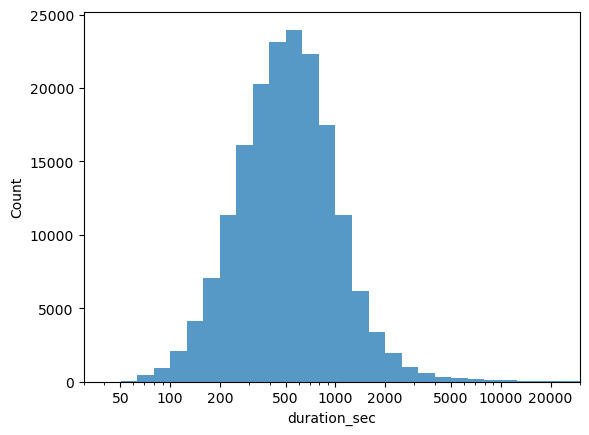

```python
bin_size = 0.1
max_dur = df_clean.duration_sec.max()
bins = 10 ** np.arange(0, np.log10(max_dur) + bin_size, bin_size)
sns.histplot(data=df_clean, x='duration_sec', bins=bins);
plt.xlim(30, 30000)
plt.xscale('log')
xticks = [50, 100, 200, 500, 1000, 2000, 5000, 10000, 20000]
plt.xticks(ticks = xticks, labels=xticks);
```

We see a normal distribution in logarithmic scale.

Let's plot a boxplot in search for outliers.

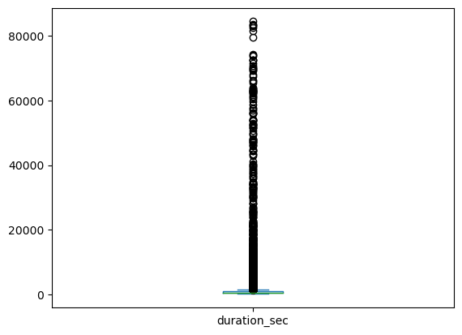

```python
df_clean.duration_sec.plot(kind='box');
```

We see many outliers. Although the is no justified reason for deleting them, it might be necessary to drop them for a comparison with other variables in a bivariate or multivariate plot if we want to have a clean plot.

#### Distance of trips (m)

We plot now a histogram with the distance of trips

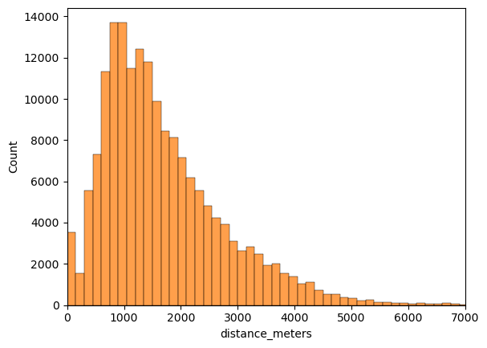

```python
bins = np.arange(0, df_clean.distance_meters.max() + 150, 150)
sns.histplot(data=df_clean, x='distance_meters', bins=bins, color='tab:orange');
plt.xlim(0, 7000);
```

We have also an exponential decay and an interesting big number of trips of distance cero, of which we will talk later.

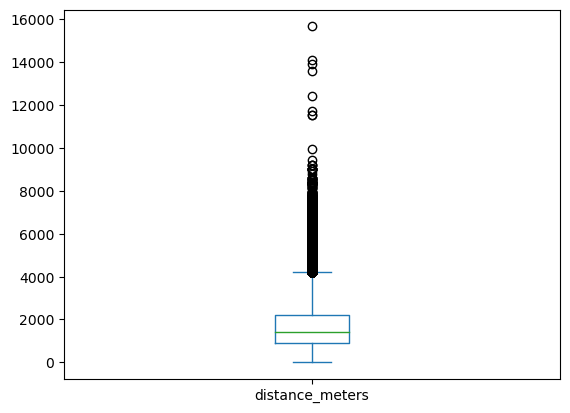

```python
df_clean.distance_meters.plot(kind='box')
```

We have the same situation than before with the duration of trips.

#### Gender

We look at the use of the service by gender

```python
# We create a function to plot the percentage on a vertical bar countplot
def print_percentage(data, column_name: str, order, x_shift = 0.2):
    '''
    This function is to be used below a count plot.
    It prints the percentage on the bars of vertical countplots
    '''

    val_counts = data[column_name].value_counts().loc[order]
    total_counts = val_counts.sum()

    max_count = val_counts.sort_values(ascending=False).iloc[0]

    for i, count in enumerate(val_counts):
        pct_string = f'{100*count/total_counts:.1f}%'
        plt.text(i - x_shift, count + 0.02 * max_count, pct_string, va='center')
```

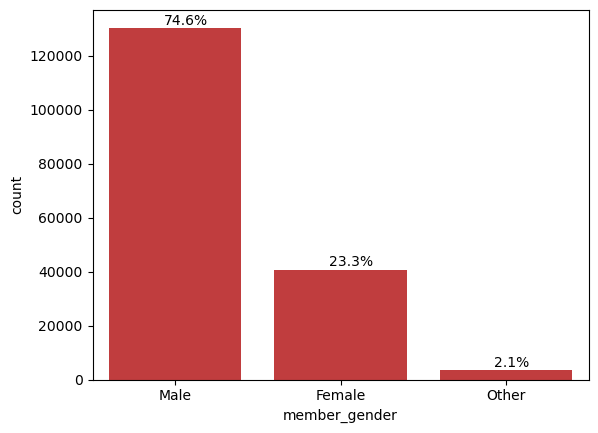

```python
# We create a plotting order
order= df_clean.member_gender.value_counts().sort_values(ascending=False).index

# We plot
sns.countplot(data=df_clean, x='member_gender', color='tab:red', order=order);
print_percentage(data=df_clean, column_name='member_gender', order=order, x_shift=0.07)
```

It is surprising how the number of male users exceed the female users. We will try to find a possible explanation to this in the following section.

#### User type

We plot the use of the service by user type.

```python
df_clean['user_type'].value_counts().index
```

```
Index(['Subscriber', 'Customer'], dtype='object')
```

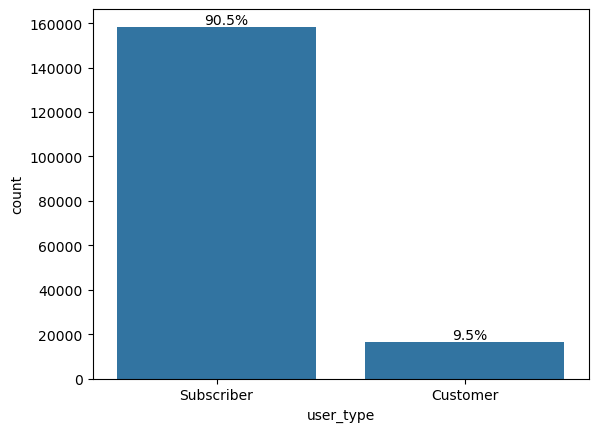

```python
order = df_clean.user_type.value_counts().index
sns.countplot(data=df_clean, x='user_type', color='tab:blue', order=order);
print_percentage(data=df_clean, column_name='user_type', order=order, x_shift=0.05)
```

Most users are subscribers by far

#### Members age

We would also like to have a distribution by ages of users. We will have to calculate them first.

```python
# We create a new column with the users age
df_clean['users_age'] = 2019 - df_clean['member_birth_year']
```

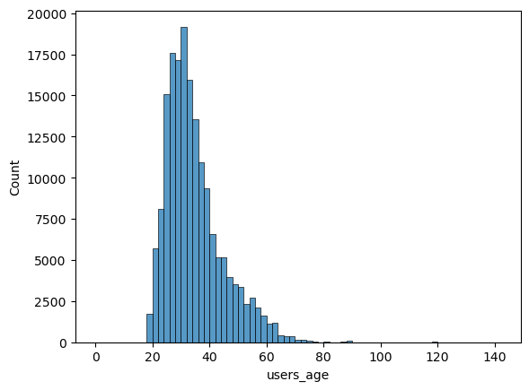

```python
# We plot the histogram of ages
bins = np.arange(0, 142 + 2, 2)
sns.histplot(data=df_clean, x='users_age', bins=bins);
```

We wil have a closer look at ages above 80

```
(0.0, 150.0)
```

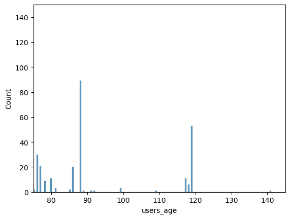

```python
sns.histplot(data=df_clean, x='users_age')
plt.xlim(75, 145)
plt.ylim(0,150)
```

There are clearly unaccuracy in these values, as we find so many users with ages over 100. It is also hard to belive that there are so many people close to 90 years old using the bike service. We decide to delete all values of ages above 85.

```python
idx = df_clean[df_clean['users_age'] > 85].index
df_clean = df_clean.drop(index=idx)
```

```python
# We check the changes
df_clean.users_age.describe()
```

```
count    174764.000000
mean         34.126611
std           9.881034
min          18.000000
25%          27.000000
50%          32.000000
75%          39.000000
max          85.000000
Name: users_age, dtype: float64
```

We plot the results after the cleaning

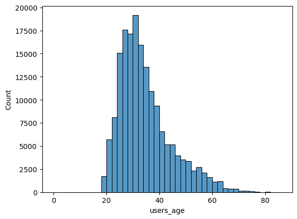

```python
bins = np.arange(0, 85 + 2, 2)
sns.histplot(data=df_clean, x='users_age', bins=bins);
```

We see that bike rentals is more popular among young people, with a peak on the age of 30, and then the number decrease progresively with age.

#### Days of use

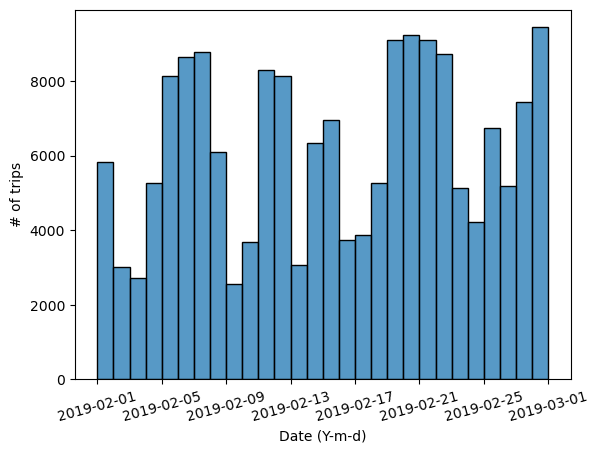

```python
# We plot the trips distribution in time during the whole month
sns.histplot(data=df_clean, x='start_time', bins=28)
plt.xticks(rotation=15);
plt.ylabel('# of trips')
plt.xlabel('Date (Y-m-d)')
```

It seems that the number of trips is higher during weekdays and lower during weekends. Lest'us look deeper into it.

In order to analyce the use of bike rental on the different days of the week, we will label dates by day of the week. And also we create a label for ordinary weekdays and weekend days. Then we will plot a barchart for the use on every day of the week.

```python
# We create the new columns in our dataframe
df_clean['day_week'] = 0
df_clean['weekend'] = 'Ordinary'

# We associate week days to dates
fr = np.arange(1, 28, 7)
sa = np.arange(2, 28, 7)
su = np.arange(3, 28, 7)
mo = np.arange(4, 28, 7)
tu = np.arange(5, 28, 7)
we = np.arange(6, 28, 7)

# We create the labels
for i in np.arange(1, 29, 1):

    # We create the datetime intervals by days
    start = dt.datetime(2019, 2, i)

    if i != 28:
        end = dt.datetime(2019, 2, i + 1)
    else:
        end = dt.datetime(2019, 3, 1)

    idx = df_clean[(df_clean['start_time'] > start) & (df_clean['start_time'] < end)].index


    if i in fr:
        df_clean['day_week'][idx] = 'Friday'
    elif i in sa:
        df_clean['day_week'][idx] = 'Saturday'
        df_clean['weekend'][idx] = 'Weekend'
    elif i in su:
        df_clean['day_week'][idx] = 'Sunday'
        df_clean['weekend'][idx] = 'Weekend'
    elif i in mo:
        df_clean['day_week'][idx] = 'Monday'
    elif i in tu:
        df_clean['day_week'][idx] = 'Tuesday'
    elif i in we:
        df_clean['day_week'][idx] = 'Wednesday'
    else:
        df_clean['day_week'][idx] = 'Thursday'

# We create a class for the day of the week
days = ['Monday', 'Tuesday', 'Wednesday', 'Thursday', 'Friday', 'Saturday', 'Sunday']
dayclass = pd.CategoricalDtype(ordered=True, categories=days)
df_clean['day_week'] = df_clean['day_week'].astype(dayclass)
```

[output not shown]

[output cut: 125 more lines]

[output not shown]

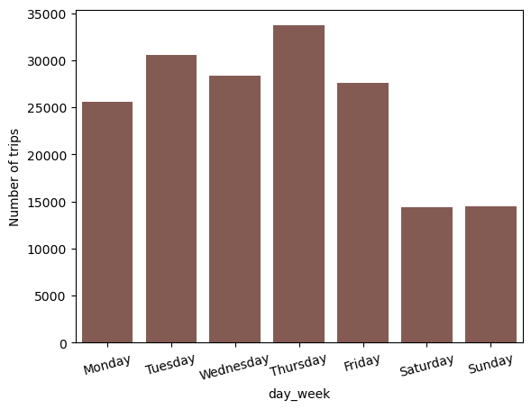

```python
# We plot the frecuency of trips on the different days of the week

color=sns.color_palette()[5]
sns.countplot(data=df_clean, x='day_week', color=color)
plt.ylabel('Number of trips')
plt.xticks(rotation=15);
```

We confirm that the use of the bike service is smaller on the weekends. It points out that these bikes are probably used by people to go to work. We will further investigate this in the next section.

#### Stations popularity

Les's have a look at the popularity distribution

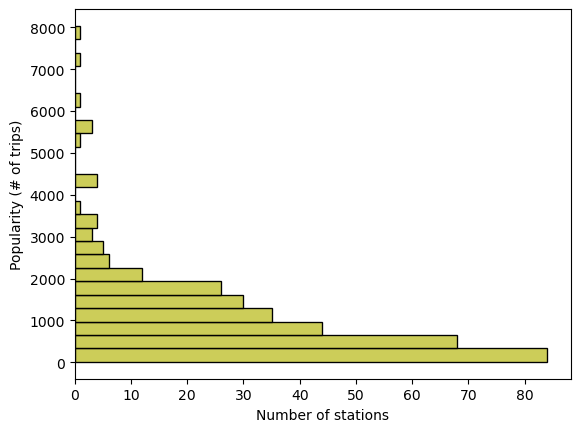

```python
order = df_stations.station_popularity.sort_values(ascending=False).index
sns.histplot(data=df_stations, y='station_popularity', color=sns.color_palette()[8])
plt.xlabel('Number of stations')
plt.ylabel('Popularity (# of trips)')
```

Less popular stations are more common than higher popularity stations.

#### Bike availability coeficient

We plot a histogram qith the distribution of the bike availability coefficient

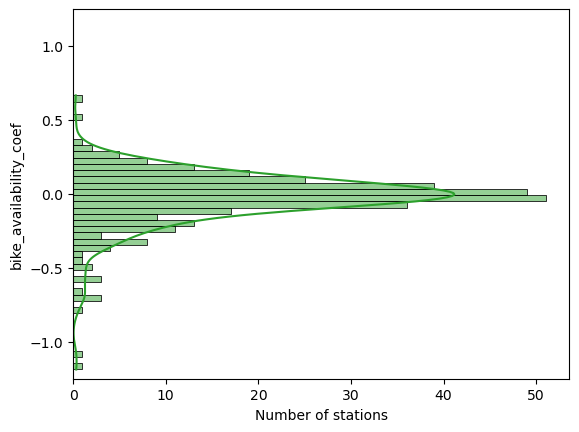

```python
sns.histplot(data=df_stations, y='bike_availability_coef', color=sns.color_palette()[2], kde=True)
plt.ylim(-1.25, 1.25)
plt.xlabel('Number of stations');
```

Most stations have a balance between incoming and outgoing bikes, as we see a distribution centered in 0. We observe though a slight asimetry towards negative values, which mean that the number of outgoing bikes is bigger than the incoming.

### Of the features you investigated, were there any unusual distributions? Did you perform any operations on the data to tidy, adjust, or change the form of the data? If so, why did you do this?

We had logarithmic distributions and outliers. We did not drop the outliers but we will probably have to do this on the next section. As we had information on two observational units, bike trips and stations, we splited the original dataframe in two dataframes, one with the information about trips and one with information about stations. In order to analyce the use of the service by day of the week, we add labels for days of the week and specified whether they are weekdays or weekends.

## Bivariate Exploration

We will draw a heatmap comparing duration and distance

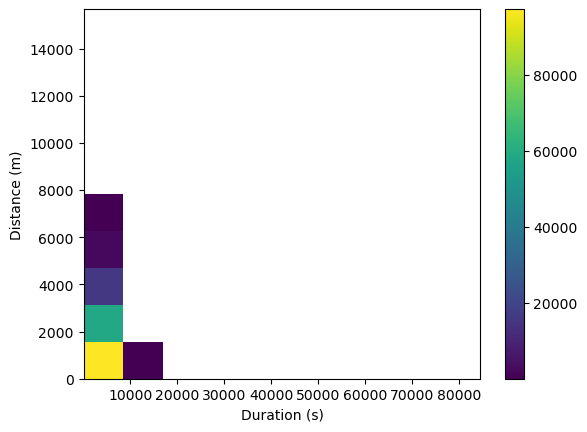

```python
plt.hist2d(data=df_clean, x='duration_sec', y='distance_meters', cmin=100);
plt.xlabel('Duration (s)')
plt.ylabel('Distance (m)')
plt.colorbar();
```

The big amount of outliers prevent us from getting a good plot. We will remove those outliers and create the plot again.

```python
# We define a function which removes outliers

def drop_outliers_IQR(data, column_name):
   '''
   This function drops outliers from the values in a column in a dataframe and returns a copy of the dataframe without outliers.
   It drops al values outside the interval (mean - 1.5*IQR, mean + 1.5*IQR)
   Being IQR the interquartile range.
   '''
# We calculate the quartiles
   Q1 = np.quantile(data[column_name], 0.25)
   Q3 = np.quantile(data[column_name], 0.75)

# We calculate the interquartile range
   IQR = Q3 - Q1


# We calculate the mean value
   mean = np.mean(data[column_name])

# We find and drop outliers
   out_idx = data[(data[column_name] < mean - 1.5 * IQR) | (data[column_name] > mean + 1.5 * IQR)].index
   data_without_outliers = data.drop(index=out_idx)
   return data_without_outliers
```

```python
# We create a dataframe without outliers in duration and distance
df_clean_out = drop_outliers_IQR(df_clean, 'distance_meters').reset_index(drop=True)
df_clean_out = drop_outliers_IQR(df_clean_out, 'duration_sec').reset_index(drop=True)
```

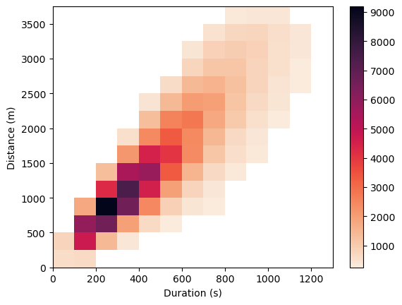

```python
# We plot our dataframe without outliers
x_bins = np.arange(0, df_clean_out['duration_sec'].max() + 50, 100)
y_bins = np.arange(0, df_clean_out['distance_meters'].max() + 250, 250)
plt.hist2d(data=df_clean_out, x='duration_sec', y='distance_meters', cmin=250, cmap='rocket_r', bins=[x_bins, y_bins]);
plt.xlabel('Duration (s)')
plt.ylabel('Distance (m)')
plt.colorbar();
```

We see that most trips cover a distance of arround 1 km in arround 5 minutes.

It seems to be some correlation between both variables as expected. It makes sense because it takes longer to cover longer distances.

Now we will analyce the users age in the different days of the week

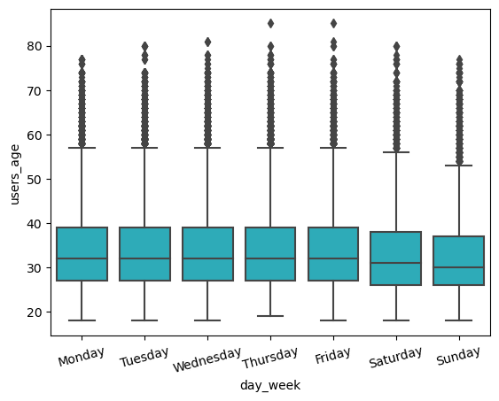

```python
sns.boxplot(data=df_clean, x='day_week', y='users_age', color=sns.color_palette()[9])
plt.xticks(rotation=15);
```

We see a quite constant distribution in ages on weekdays, and a more variable use on the weekends. More young people use the service on the weekend compared to weekdays. This difference from weekdays and weekends suggest a use of bikes as a work mean of transport.

[figure not shown]

```python
plt.figure(figsize=[10, 4])

# We plot the trips distribution in time during one ordinary day
start_wd = dt.datetime(2019, 2, 5)
end_wd = dt.datetime(2019, 2, 6)
df_weekday_sample = df_clean[(df_clean['start_time'] > start_wd) & (df_clean['start_time'] < end_wd)]

plt.subplot(1, 2, 1)
sns.histplot(data=df_weekday_sample, x='start_time', bins=24)
plt.xticks(rotation=25);
plt.title('Use on a weekday')
plt.ylim(0, 1200)
plt.ylabel('Number of trips')

# We plot the trips distribution in time on a saturday

start_wend = dt.datetime(2019, 2, 10)
end_wend = dt.datetime(2019, 2, 11)
df_weekend_sample = df_clean[(df_clean['start_time'] > start_wend) & (df_clean['start_time'] < end_wend)]

plt.subplot(1, 2, 2)
sns.histplot(data=df_weekend_sample, x='start_time', bins=24)
plt.xticks(rotation=25);
plt.title('Use on saturday');
plt.ylim(0, 1200)
plt.ylabel('')
```

On the weekend we observe a normal distribution during the day, whereas on weekdays we observe a big afluency during rush hours, which overcomes by far the normal use on weekends. This distribution supports our hipotesis of bike use as a mean of transport to go to work.

As we saw before, this bike service is used much more by men rather than by women. This information together with what we have just discovered make us come up with some questions: Do women prefer other means of transport rather than bike? Or maybe we still live in a system in which men go to work and women stay at home?

We will explore the relationship between the bike availability coefficient and the popularity of stations

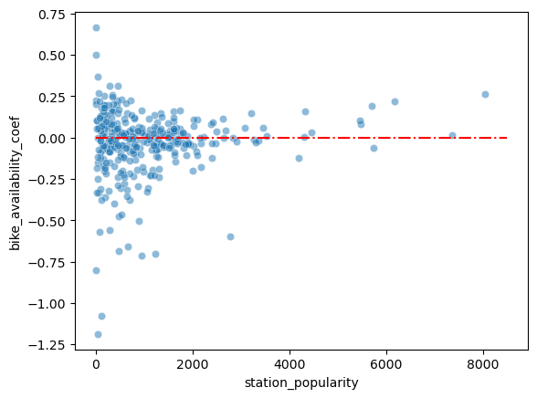

```python
sns.scatterplot(data=df_stations, x='station_popularity', y='bike_availability_coef', alpha=0.5)
plt.plot([0, 8500], [0, 0], 'r-.');
```

We observe a higher tendency for a positive coefficient (which means more incoming bikes than outgoing) in stations with higher popularity.

### Talk about some of the relationships you observed in this part of the investigation. How did the feature(s) of interest vary with other features in the dataset?

- **Duration and distance:** we see a positive correlation as spected
- **Time of trips and weekday:** we observe a hughe increase in the number of trips during rush hours on weekdays. It makes us think that this bike system is used as a mean of transport for people to go to work.
- **Bike availability coefficient and station popularity:** more popular stations usually have a positive availability coefficient, which means that there more incoming bikes than outgoing.

### Did you observe any interesting relationships between the other features (not the main feature(s) of interest)?

- **Weekday and users age:** we observe that weekend users are younger than on weekdays

## Multivariate Exploration

We will create a scattermatrix with all numeric variables that have a physical meaning. For this plotting we will use a small random sample of our data.

```python
# We create a function to take samples from a dataframe
def random_sample(data, n, seed = 0):
    '''This function takes a random sample from a dataframe
    data: Dataframe, n: size of the sample'''
    assert n < data.shape[0], 'n must be smaller than the number of rows of the dataframe'
    np.random.seed(seed)
    sample_idx = np.random.choice(data.shape[0], n, replace=False)
    return data.loc[sample_idx]
```

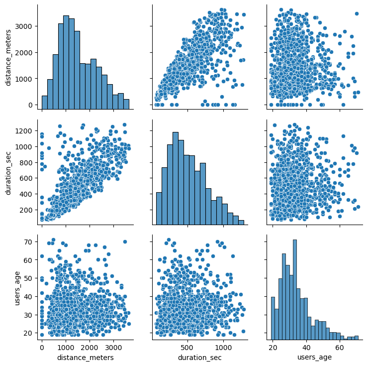

```python
# We take the sample
df_clean_out_sample = random_sample(df_clean_out, 1000)

# We create the matrix
num = ['distance_meters', 'duration_sec', 'users_age']
g = sns.PairGrid(data=df_clean_out_sample, vars=num)
g.map_offdiag(sns.scatterplot)
g.map_diag(sns.histplot)
```

We do not see any interesting trend besides the already detected distance-duration relationship. In this distance-duration scatterplot we do not observe any points on the upper left side of the plot. We could draw a line representing the maximum speed that bikers are not able to exceed. It is interesting to notice that there are many trips of distance cero. It does not mean that they are no real trips, they just mean that the start and end station are the same and we can think of them as round trips.

Now we will draw a Facet plot comparing the age distribution by gender and wheather it is a weekday or weekend.

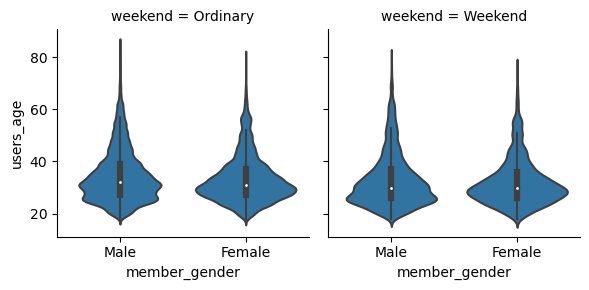

```python
# We create the plot
g = sns.FacetGrid(data=df_clean_out, col='weekend')
g.map(sns.violinplot, 'member_gender','users_age', order=['Male', 'Female'])
```

We observe bimodal distribution in males and unimodal distribution in females. We observe no big differences from weekdays and weekends.

### Talk about some of the relationships you observed in this part of the investigation. Were there features that strengthened each other in terms of looking at your feature(s) of interest?

In the scattermatrix we came up with the same conclusions than on the heatmap in the previous section and discover the existence of some roundtrips. It seems to be no correlation between the age of the users and the distance or the duration of trips.

We found that the distribution of users age is different in male and in women in both weekdays and weekend.

### Were there any interesting or surprising interactions between features?

We found an imaginary line representing the maximum speed that bikers can not exceed.

## Conclusions

In this exploration, after describing and cleaning our dataset we made different kind of explorations, in this order: univariate, bivariate and multivariate explorations.

We have investigated a dataset of the Ford GoBike bike-rental service. We made different kind of explorations of the variables present in the dataframe: univariate, bivariate and multivariate explorations.

On univariate explorations we analyced: duration of trips, distances covered by trips, age of users, user types, users gender, use of the service over time and on the different week days, stations popularity and stations balance between incoming and outgoing bikes.

On bivariate explorations we analyced: distance-duration relationship, users age by day of the week, use over time on a weekday and on a day of the weekend and station popularity and bike availability relationship.

And on the multivariate exploration we made a scattermatrix on the variables distance, duration and users age, and a facet grid comparing users age and gender on a normal weekday and a day of the weekend.

Our main finding are the following:

- We found out that the big majority of users (90.5%) are suscribers and not regular cutomers.
- We found that stations with a low popularity are much more numerous than those with a high popularity.
- We also analyced the balanced between incoming and outgoing bikes from stations, and we found that the majority of stations are balanced, and in the most popular stations the tendency is to have more incoming bikes than outgoing on this month, this year.
- Ages of users, distances covered and duration of trips have an exponential decay after a maximum peak. We explored the relationship first between duration and distance covered by trips and then the relationship between these variables and the users age.
- We found out that the number of trips is considerably lower on the weekends compared to weekdays and we found that on weekdays the number of trips during rush hours is much higher. This take us to the conclusion that **this bike service is mainly used as a mean of transport to go to work**, which is good explanation for other of our findings: the median age of users is lower during the weekend.
- It was surprising to find an incredibly big difference between the number of male and female users, where male users represent the 74.6%. The age distribution of male is slightly bimodal and of female is unimodal. We found no explanation for this big difference between genders. Do women usually prefer other means of transport? If this is the case we should wonder why. Or maybe are there still less women working outside home? These questions could be approach on a different investigation.

```python
# Make directory if it doesn't already exist
folder_name = 'cleaned_datasets'
if not os.path.exists(folder_name):
    os.makedirs(folder_name)

# We store our clean data
df_clean.to_csv('./cleaned_datasets/201902_bikerental_clean.csv')
df_stations.to_csv('./cleaned_datasets/201902_bikestations.csv')
```

```python
# We save this notebook as an html file
!jupyter nbconvert Part_I_exploration_template.ipynb --to html
```

```
[NbConvertApp] Converting notebook Part_I_exploration_template.ipynb to html
[NbConvertApp] Writing 1511163 bytes to Part_I_exploration_template.html
```